# Lab Week 11 - Clustering

Pouria

4/11/2022

```r
library(ggplot2)
library(mvtnorm)
library(Matrix)
```

# a) Generate the simulated data

- Generate a simulated data set with 20 observations in each of three classes (i.e. 60 observations total), and 50 variables.

```r
# set.seed(123)
# x <- matrix(rnorm(20 * 3 * 50, mean = 0, sd = 1), ncol = 50)
# x[1:20, 2] <- 1
# x[21:40, 1] <- 2
# x[21:40, 2] <- 2
# x[41:60, 1] <- 1
# true.labels <- factor(c(rep(1, 20), rep(2, 20), rep(3, 20)))
```

```r
set.seed(123)

n.obs = 600
n.var = 50

data = matrix(, nrow = 0, ncol = 50)

mu = c(0,0,0)
sig= c(1, 1, 1)

for (i in 1:3){

  center = rnorm(50, 0, 2)
  # sigma = matrix(rnorm(n.var*n.var, 0, 10), ncol = n.var)
  # sigma = matrix(runif(n.var*n.var, 0, 70), ncol = n.var)
  #
  # ind <- lower.tri(sigma)
  # sigma[ind] <- t(sigma)[ind]

  sigma <- matrix(runif(n.var^2)*2-1, ncol=n.var)
  sigma <- t(sigma) %*% sigma

  # sigma = diag(n.var)

  # data[n.obs/3*(i-1)+1:n.obs/3,] = rmvnorm(n.obs/3, mean = center, sigma = sigma)

  data = rbind(data, rmvnorm(n.obs/3, mean = center, sigma = sigma))
}
x = data
true.labels <- factor(c(rep(1, n.obs/3), rep(2, n.obs/3), rep(3, n.obs/3)))
```

```r
# pr.out <- prcomp(x)
#
# summary(pr.out)$importance[1,1:10]
#
# df.pca <- data.frame(pr.out$x[, 1:2], true.labels)
#
# ggplot(df.pca) +
#   geom_point(aes(PC1, PC2, col = true.labels))
```

# Check the mean and variance of the variables

```r
cumsum(apply(x, 2, mean))
```

```
##  [1]  0.4690618 -1.2402629 -0.5304056  0.5617975  0.4888938 -0.2063417
##  [7]  1.0801870  1.3841091  0.7807019  1.6848235  3.1299865  4.7634032
## [13]  5.0145396  5.6772623  5.7441319  7.7219870  9.5337362  7.6850466
## [19]  6.7563842  7.2641216  6.2430544  5.5475443  4.5615905  4.7264308
## [25]  4.7178299  6.1795236  6.9776835  6.4575051  4.0451658  6.1907067
## [31]  7.2573137  8.1733693  9.0177313  8.2890534  8.3156928  9.2268863
## [37]  8.8010603  9.8781200  9.4709986  9.5820380  7.8295353 10.1187404
## [43]  9.5418475 12.1414285 13.2508777 11.3508259  9.6796948  8.5800160
## [49]  8.6221544  8.0049011
```

```r
cumsum(apply(x, 2, var))
```

```
##  [1]  17.63258  33.42568  55.75716  76.00649  92.87212 122.48142 141.89850
##  [8] 159.14949 175.05060 193.48585 211.99441 230.89642 250.37972 267.02296
## [15] 287.36833 306.67084 325.77570 347.20484 366.09311 391.08942 411.88432
## [22] 428.92876 446.49273 464.78319 480.50172 510.82474 526.53135 545.10793
## [29] 562.15057 578.48242 600.72802 617.46682 642.06039 660.21250 679.84181
## [36] 699.38744 720.29640 735.99715 757.23750 774.80404 793.08191 814.38712
## [43] 834.01325 852.18680 871.54225 893.45439 912.28741 927.47747 952.20148
## [50] 968.90288
```

# b) PCA and plot the first two PC scores

**Note 1**: This part is used for visualization for now and to hint the user on if they need to revisit part (a) and fix the distribution.

**Note 2**: The results are going to be directly used in part (f).

- Perform PCA on the `60` observations and plot the **first two principal component** score vectors. Use a different color to indicate the observations in each of the three classes. If the three classes appear separated in this plot, then continue on to part (c). If not, the return to part (a) and modify the simulation so that there is greater separation between the three classes. Do not continue to part (c) until the three classes show at least some separation in the first two principal component score vectors.

```r
pr.out <- prcomp(x)

summary(pr.out)$importance[3,]
```

```
##     PC1     PC2     PC3     PC4     PC5     PC6     PC7     PC8     PC9    PC10
## 0.11066 0.18198 0.22401 0.26317 0.30120 0.33702 0.37104 0.40458 0.43741 0.46737
##    PC11    PC12    PC13    PC14    PC15    PC16    PC17    PC18    PC19    PC20
## 0.49466 0.52030 0.54589 0.57031 0.59370 0.61606 0.63738 0.65814 0.67745 0.69650
##    PC21    PC22    PC23    PC24    PC25    PC26    PC27    PC28    PC29    PC30
## 0.71496 0.73273 0.75027 0.76699 0.78322 0.79884 0.81392 0.82763 0.84094 0.85316
##    PC31    PC32    PC33    PC34    PC35    PC36    PC37    PC38    PC39    PC40
## 0.86437 0.87550 0.88614 0.89653 0.90620 0.91554 0.92472 0.93367 0.94158 0.94910
##    PC41    PC42    PC43    PC44    PC45    PC46    PC47    PC48    PC49    PC50
## 0.95626 0.96263 0.96863 0.97456 0.97981 0.98483 0.98951 0.99351 0.99711 1.00000
```

# Plot

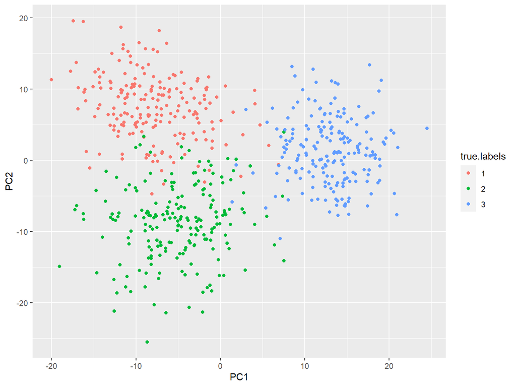

```r
df.pca <- data.frame(pr.out$x[, 1:2], true.labels)

ggplot(df.pca) +
  geom_point(aes(PC1, PC2, col = true.labels))
```

# c) K-means Clustering with `K=3`

- Perform K-means clustering of the observations with `K=3`. How well do the clusters that you obtained in K-means clustering compare to the true class labels ?

```r
km.out <- kmeans(x, 3, nstart = 20)
table(true.labels, km.out$cluster)
```

```
##
## true.labels   1   2   3
##           1   4   7 189
##           2 190   4   6
##           3   1 199   0
```

# d) K-means Clustering with `K=2`

- Perform K-means clustering with `K=2`. Describe your results.

```r
km.out <- kmeans(x, 2, nstart = 20)
table(true.labels, km.out$cluster)
```

```
##
## true.labels   1   2
##           1   5 195
##           2   7 193
##           3 198   2
```

# e) K-means Clustering with `K=4`

- Now perform K-means clustering with `K=4`, and describe your results.

```r
km.out <- kmeans(x, 4, nstart = 20)
table(true.labels, km.out$cluster)
```

```
##
## true.labels   1   2   3   4
##           1 189   5   1   5
##           2   6 190   3   1
##           3   0   1  90 109
```

# f) K-means Clustering with `K=3` on the first two PCs

- Now perform K-means clustering with `K=3` on the first two principal component score vectors, rather than on the raw data.

```r
# km.out <- kmeans(pr.out$x[, 1:2], centers = sort(kmeans(pr.out$x[, 1:2], centers = 3, nstart=20)$centers), nstart = 20)
km.out <- kmeans(pr.out$x[, 1:2], 3, nstart=20)
table(true.labels, km.out$cluster)
```

```
##
## true.labels   1   2   3
##           1   7 187   6
##           2 188   8   4
##           3   4   0 196
```

# g) K-means Clustering with `K=3` after scaling

- Using the `scale()` function, perform K-means clustering with `K=3` on the data after scaling each variable to have standard deviation one. How do these results compare to those obtained in (b) ? Explain.

```r
km.out <- kmeans(scale(x), 3, nstart = 20)
table(true.labels, km.out$cluster)
```

```
##
## true.labels   1   2   3
##           1   6   8 186
##           2   3 193   4
##           3 198   2   0
```